# Song Data Project

Kristian Abad & Steven Truong

2/13/2022

# Introduction

The purpose of this project is to observe the relationship between the popularity of songs based on its characteristics and generate a model that will predict the song’s popularity based on given characteristics.

# What Are The Characteristics Of Music?

The characteristics of music are the audio features of a song. In our dataset, we were given numeric data for features such as the song’s duration, acousticness, danceability, energy, instrumentalness, key, liveliness, loudness, audio mode, speechiness, tempo, time signature, and audio valence. The combination of these audio features makes up what we hear. According to Spotify APIs, these features can be categorized in which aspect of a song that it can affect:

- Mood: Danceability, Valence, Energy, Tempo
- Properties: Loudness, Speechiness, Instrumentalness
- Context: Liveness, Acousticness

We were also given a descriptions and range of unit of each audio feature:

- Duration: The duration of the track in milliseconds.
- Acousticness: A confidence measure from 0.0 to 1.0 of whether the track is acoustic. 1.0 represents high confidence the track is acoustic.
- Danceability: Describes how suitable a track is for dancing based on a combination of musical elements including tempo, rhythm stability, beat strength, and overall regularity. A value of 0.0 is least danceable and 1.0 is most danceable.
- Energy: A measure from 0.0 to 1.0 and represents a perceptual measure of intensity and activity. Typically, energetic tracks feel fast, loud, and noisy. For example, death metal has high energy, while a Bach prelude scores low on the scale. Perceptual features contributing to this attribute include dynamic range, perceived loudness, timbre, onset rate, and general entropy.
- Instrumentalness: Predicts whether a track contains no vocals. “Ooh” and “aah” sounds are treated as instrumental in this context. Rap or spoken word tracks are clearly “vocal”. The closer the instrumentalness value is to 1.0, the greater likelihood the track contains no vocal content. Values above 0.5 are intended to represent instrumental tracks, but confidence is higher as the value approaches 1.0.
- Key: The key the track is in. Integers map to pitches using standard Pitch Class notation. E.g. 0 = C, 1 = C♯/D♭, 2 = D, and so on. If no key was detected, the value is -1.
- Liveliness: Detects the presence of an audience in the recording. Higher liveness values represent an increased probability that the track was performed live. A value above 0.8 provides strong likelihood that the track is live.
- Loudness: The overall loudness of a track in decibels (dB). Loudness values are averaged across the entire track and are useful for comparing relative loudness of tracks. Loudness is the quality of a sound that is the primary psychological correlate of physical strength (amplitude). Values typically range between -60 and 0 db.
- Mode: Mode indicates the modality (major or minor) of a track, the type of scale from which its melodic content is derived. Major is represented by 1 and minor is 0.
- Speechiness: Detects the presence of spoken words in a track. The more exclusively speech-like the recording (e.g. talk show, audio book, poetry), the closer to 1.0 the attribute value. Values above 0.66 describe tracks that are probably made entirely of spoken words. Values between 0.33 and 0.66 describe tracks that may contain both music and speech, either in sections or layered, including such cases as rap music. Values below 0.33 most likely represent music and other non-speech-like tracks.
- Tempo: The overall estimated tempo of a track in beats per minute (BPM). In musical terminology, tempo is the speed or pace of a given piece and derives directly from the average beat duration.
- Time Signature: An estimated time signature. The time signature (meter) is a notational convention to specify how many beats are in each bar (or measure). The time signature ranges from 3 to 7 indicating time signatures of “3/4”, to “7/4”.
- Valence: A measure from 0.0 to 1.0 describing the musical positiveness conveyed by a track. Tracks with high valence sound more positive (e.g. happy, cheerful, euphoric), while tracks with low valence sound more negative (e.g. sad, depressed, angry).

In addition to the audio feature, the dataset also provided the name of songs and how it ranked in popularity from a range of 0 to 100 (where 0 is the lowest popularity and 100 is the highest popularity).

# Why Might The Model Be Useful?

It is in the interest of music artists and companies to produce songs that will rank high in popularity and top the charts. By having some knowledge of what music listeners generally enjoy, artists will be able to incorporate more of what people want and this will lead to a higher success of the song.

# Loading Data and Packages

```r
library(readr)
library(tidyr)
library(tidyverse)
```

```r
library(ggplot2)
library(dplyr)
library(class)
library(FNN)
library(glmnet)
```

# Data Cleaning

When observing the raw dataset, we saw that they are multiple songs that are repeated. We assumed that there was some error in the raw data, so we decided to get rid of the duplicate. However, some songs have the same title, but they have different popularity scores and audio features values. We decided to leave those data assuming that they are remixes.

```r
data = read_csv("data/song_data.csv")
head(data)
```

```
## # A tibble: 6 x 15
##   song_name    song_popularity song_duration_ms acousticness danceability energy
##   <chr>                  <dbl>            <dbl>        <dbl>        <dbl>  <dbl>
## 1 Boulevard o~              73           262333     0.00552         0.496  0.682
## 2 In The End                66           216933     0.0103          0.542  0.853
## 3 Seven Natio~              76           231733     0.00817         0.737  0.463
## 4 By The Way                74           216933     0.0264          0.451  0.97
## 5 How You Rem~              56           223826     0.000954        0.447  0.766
## 6 Bring Me To~              80           235893     0.00895         0.316  0.945
## # ... with 9 more variables: instrumentalness <dbl>, key <dbl>, liveness <dbl>,
## #   loudness <dbl>, audio_mode <dbl>, speechiness <dbl>, tempo <dbl>,
## #   time_signature <dbl>, audio_valence <dbl>
```

One challenge we need to figure out is addressing the following cases in our data, if there are any:

- Remixes
- Remasters
- Single Versions
- Same name but different artists?
- Radio edits
- Extended versions
- Misc mixes/versions  
  I think maybe we can leave remixes possibly treating them as reimaginings of songs or somewhat to the same vein that songs have samples from other tracks are in themselves a separate track. Maybe the more difficult is dealing with the other cases. An example that comes to mind is “Smooth Operator” by Sade (seems like only one of the 3 versions is in the data). There’s a single version, a remastered version, and I believe an album version where there’s an immediate difference between the remastered and album version.  
  I think the duplicated() function finds exact duplicates of rows.

```r
duplicates <- data[duplicated(data),]
duplicates
```

```
## # A tibble: 3,909 x 15
##    song_name   song_popularity song_duration_ms acousticness danceability energy
##    <chr>                 <dbl>            <dbl>        <dbl>        <dbl>  <dbl>
##  1 Sex on Fire              81           203346      0.00172        0.542  0.905
##  2 Use Somebo~              79           230760      0.00552        0.276  0.715
##  3 Hips Don't~              84           218093      0.284          0.778  0.824
##  4 Hotel Cali~              83           391376      0.00574        0.579  0.508
##  5 Me and Bob~              69           271333      0.302          0.453  0.464
##  6 Imagine - ~              77           187866      0.907          0.547  0.257
##  7 Let It Be ~              78           243026      0.631          0.443  0.403
##  8 Rocket Man~              80           281613      0.386          0.602  0.522
##  9 My Sweet L~              78           281226      0.0794         0.538  0.704
## 10 Tangled up~              63           341626      0.414          0.421  0.661
## # ... with 3,899 more rows, and 9 more variables: instrumentalness <dbl>,
## #   key <dbl>, liveness <dbl>, loudness <dbl>, audio_mode <dbl>,
## #   speechiness <dbl>, tempo <dbl>, time_signature <dbl>, audio_valence <dbl>
```

Just testing some cases here…while scrolling through on kaggle, I just picked a random duplicate song to test

```r
duplicates %>%
  filter(song_name == 'Zombie')
```

```
## # A tibble: 1 x 15
##   song_name song_popularity song_duration_ms acousticness danceability energy
##   <chr>               <dbl>            <dbl>        <dbl>        <dbl>  <dbl>
## 1 Zombie                 82           306410       0.0163        0.299  0.613
## # ... with 9 more variables: instrumentalness <dbl>, key <dbl>, liveness <dbl>,
## #   loudness <dbl>, audio_mode <dbl>, speechiness <dbl>, tempo <dbl>,
## #   time_signature <dbl>, audio_valence <dbl>
```

Here’s an interesting case where we have 2 of the same rows and 1 with a remix with a track called “8 Letters”

```r
duplicates %>%
  filter(song_name == '8 Letters')
```

```
## # A tibble: 1 x 15
##   song_name song_popularity song_duration_ms acousticness danceability energy
##   <chr>               <dbl>            <dbl>        <dbl>        <dbl>  <dbl>
## 1 8 Letters              72           190026        0.649        0.607  0.478
## # ... with 9 more variables: instrumentalness <dbl>, key <dbl>, liveness <dbl>,
## #   loudness <dbl>, audio_mode <dbl>, speechiness <dbl>, tempo <dbl>,
## #   time_signature <dbl>, audio_valence <dbl>
```

```r
duplicates %>%
  filter(song_name == '8 Letters - R3HAB Remix')
```

```
## # A tibble: 0 x 15
## # ... with 15 variables: song_name <chr>, song_popularity <dbl>,
## #   song_duration_ms <dbl>, acousticness <dbl>, danceability <dbl>,
## #   energy <dbl>, instrumentalness <dbl>, key <dbl>, liveness <dbl>,
## #   loudness <dbl>, audio_mode <dbl>, speechiness <dbl>, tempo <dbl>,
## #   time_signature <dbl>, audio_valence <dbl>
```

So it looks like it just picks up exact duplicates and we’ll need to figure out what we’re going to do with other cases.

```r
data_2 <- data[!duplicated(data),]
nrow(data)
```

```
## [1] 18835
```

```r
nrow(data_2)
```

```
## [1] 14926
```

```r
nrow(data) - nrow(data_2)
```

```
## [1] 3909
```

Using the grepl function to find any instance of single,remastered, and radio edit/mix versions of tracks.

```r
#Function was found via stackoverflow
#https://stackoverflow.com/questions/10128617/test-if-characters-are-in-a-string
data_3 <- data_2[!(grepl('Single',data_2$song_name,fixed=TRUE) |
                 grepl('Remaster',data_2$song_name,fixed=TRUE) |
                 grepl('Radio',data_2$song_name,fixed=TRUE)),]
data_3
```

```
## # A tibble: 14,276 x 15
##    song_name   song_popularity song_duration_ms acousticness danceability energy
##    <chr>                 <dbl>            <dbl>        <dbl>        <dbl>  <dbl>
##  1 Boulevard ~              73           262333     0.00552         0.496  0.682
##  2 In The End               66           216933     0.0103          0.542  0.853
##  3 Seven Nati~              76           231733     0.00817         0.737  0.463
##  4 By The Way               74           216933     0.0264          0.451  0.97
##  5 How You Re~              56           223826     0.000954        0.447  0.766
##  6 Bring Me T~              80           235893     0.00895         0.316  0.945
##  7 Last Resort              81           199893     0.000504        0.581  0.887
##  8 Are You Go~              76           213800     0.00148         0.613  0.953
##  9 Mr. Bright~              80           222586     0.00108         0.33   0.936
## 10 Sex on Fire              81           203346     0.00172         0.542  0.905
## # ... with 14,266 more rows, and 9 more variables: instrumentalness <dbl>,
## #   key <dbl>, liveness <dbl>, loudness <dbl>, audio_mode <dbl>,
## #   speechiness <dbl>, tempo <dbl>, time_signature <dbl>, audio_valence <dbl>
```

Checking for missing values

```r
data_3[is.na(data_3)]
```

```
## <unspecified> [0]
```

```r
#data_3[grepl('Swimming Pools (Drank)',data_3$song_name,fixed=TRUE),]


#This is the only entry for this song in the dataset
#data_3[grepl("Wouldn't It Be Nice",data_3$song_name,fixed=TRUE),]
#nrow(data_3)
data_4 <- data_3[!(grepl('Mix',data_3$song_name,fixed=TRUE) |
       grepl('Version',data_3$song_name,fixed=TRUE)),]
data_4
```

```
## # A tibble: 14,050 x 15
##    song_name   song_popularity song_duration_ms acousticness danceability energy
##    <chr>                 <dbl>            <dbl>        <dbl>        <dbl>  <dbl>
##  1 Boulevard ~              73           262333     0.00552         0.496  0.682
##  2 In The End               66           216933     0.0103          0.542  0.853
##  3 Seven Nati~              76           231733     0.00817         0.737  0.463
##  4 By The Way               74           216933     0.0264          0.451  0.97
##  5 How You Re~              56           223826     0.000954        0.447  0.766
##  6 Bring Me T~              80           235893     0.00895         0.316  0.945
##  7 Last Resort              81           199893     0.000504        0.581  0.887
##  8 Are You Go~              76           213800     0.00148         0.613  0.953
##  9 Mr. Bright~              80           222586     0.00108         0.33   0.936
## 10 Sex on Fire              81           203346     0.00172         0.542  0.905
## # ... with 14,040 more rows, and 9 more variables: instrumentalness <dbl>,
## #   key <dbl>, liveness <dbl>, loudness <dbl>, audio_mode <dbl>,
## #   speechiness <dbl>, tempo <dbl>, time_signature <dbl>, audio_valence <dbl>
```

# Train/Test Split

```r
set.seed(131)
train_1 = sample(1:nrow(data_4), 11240)
music.train = data_4[train_1,]
music.test = data_4[-train_1,]

nrow(music.train)
```

```
## [1] 11240
```

```r
nrow(music.test)
```

```
## [1] 2810
```

# Exploratory Data Analysis

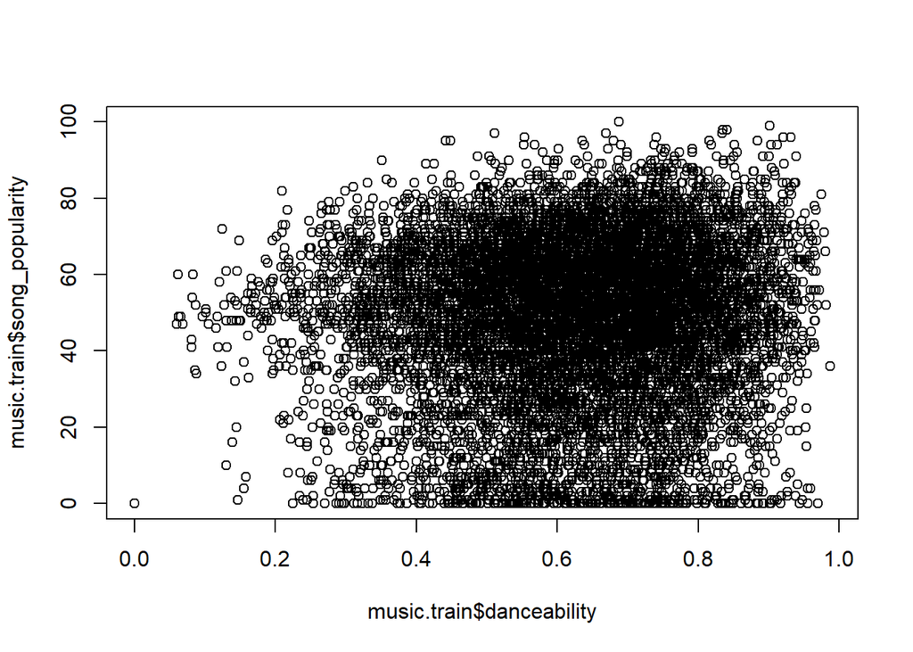

```r
plot(music.train$danceability,music.train$song_popularity)
```

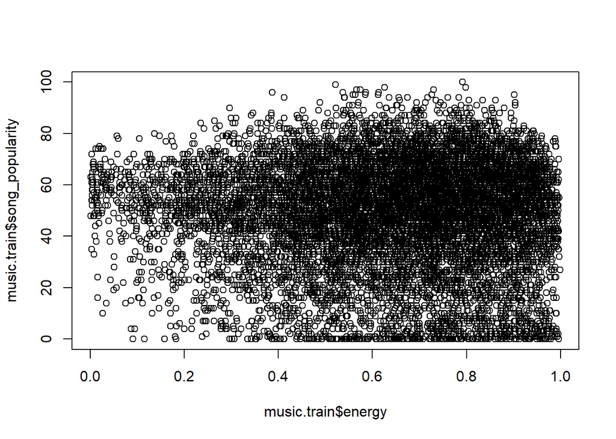

```r
plot(music.train$energy,music.train$song_popularity)
```

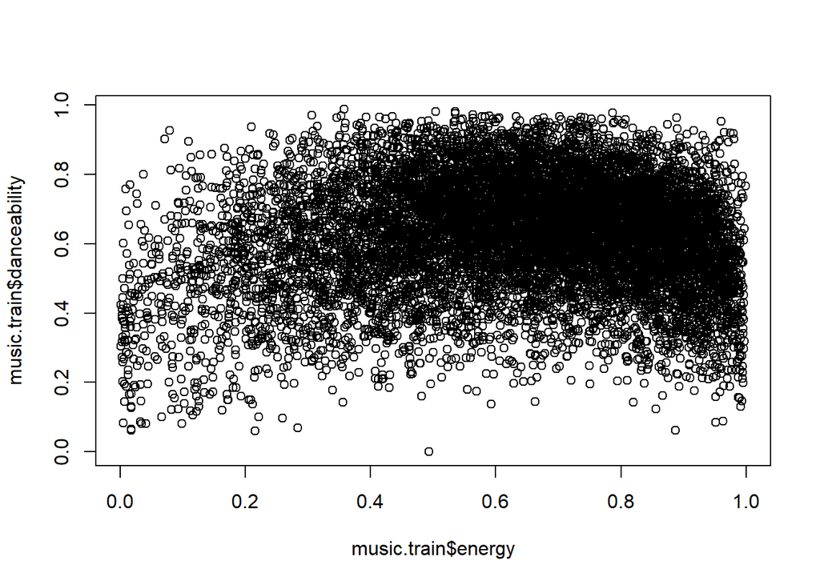

```r
plot(music.train$energy,music.train$danceability)
```

When it comes to plotting song popularity against some of the other variables such as danceability and energy, there doesn’t appear to be any immediate relationship but when it comes to plotting danceability versus energy, there appears to be some quadratic relationship among the variables.

#Linear Regression

We decided to make a histogram graph of the Popularity of our songs to observe where most of the songs were ranked in term of Popularity

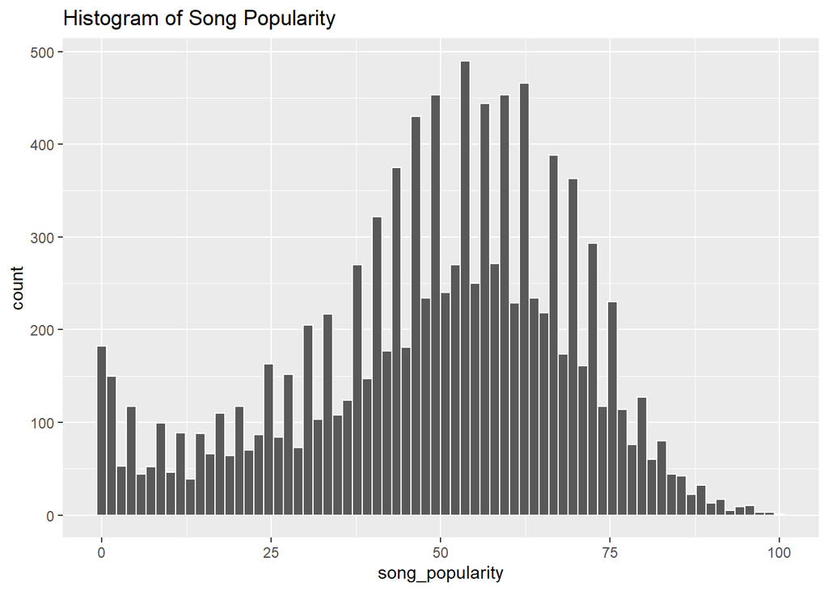

```r
ggplot(music.train, aes(song_popularity)) +
  geom_histogram(bins = 70, color = "white") +
  labs(
    title = "Histogram of Song Popularity"
  )
```

From this, we observed that most song popularity are rated in the middle where the scores are around 50 to 60 out of 100. We also see that not many songs get a score above a score of 90 out of 100. We see that there a lot more songs that are rated low popularity. We will now continue to observe the different audio features of the songs individually to see any relationship between it and the song’s popularity.

Diagnostics Test

Since we do not have any categorical value, we have to observed each features individually against the song popularity. We will perform the diagnostic test for these individuals features and also observe the p-value to see if there is any significant relationship between the individual features and the popularity.

- Linearity: evaluated by the Residuals vs Fitted plot (want horizontal line to follow assumption)
- Normality: evaluated by the Normal Q-Q plot (want y = x line to follow assumption)
- Homoscedasticity: evaluated by the Scale-location plot (want horizontal line to follow assumption)
- Influential cases (outlier): evaluated by the Residuals vs Leverage (want horizontal line to follow assumption)

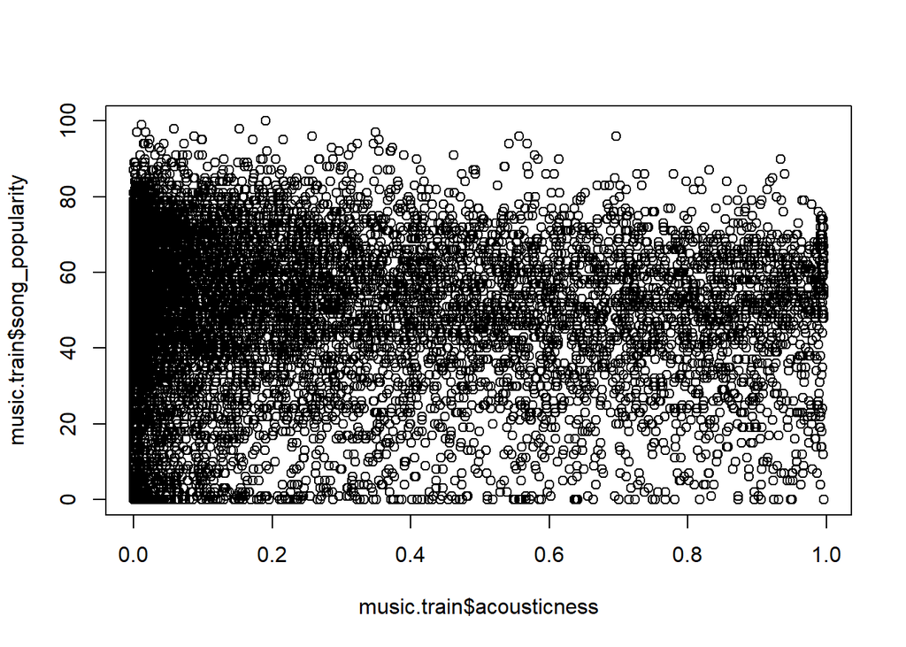

```r
plot(music.train$acousticness, music.train$song_popularity)
```

```r
mod_acc = lm(music.train$song_popularity~music.train$acousticness)
summary(mod_acc)
```

```
##
## Call:
## lm(formula = music.train$song_popularity ~ music.train$acousticness)
##
## Residuals:
##     Min      1Q  Median      3Q     Max
## -49.323 -11.427   2.882  14.727  50.987
##
## Coefficients:
##                          Estimate Std. Error t value Pr(>|t|)
## (Intercept)               49.3231     0.2596 189.982   <2e-16 ***
## music.train$acousticness  -1.6242     0.6474  -2.509   0.0121 *
## ---
## Signif. codes:  0 '***' 0.001 '**' 0.01 '*' 0.05 '.' 0.1 ' ' 1
##
## Residual standard error: 20.38 on 11238 degrees of freedom
## Multiple R-squared:  0.0005597,  Adjusted R-squared:  0.0004708
## F-statistic: 6.294 on 1 and 11238 DF,  p-value: 0.01213
```

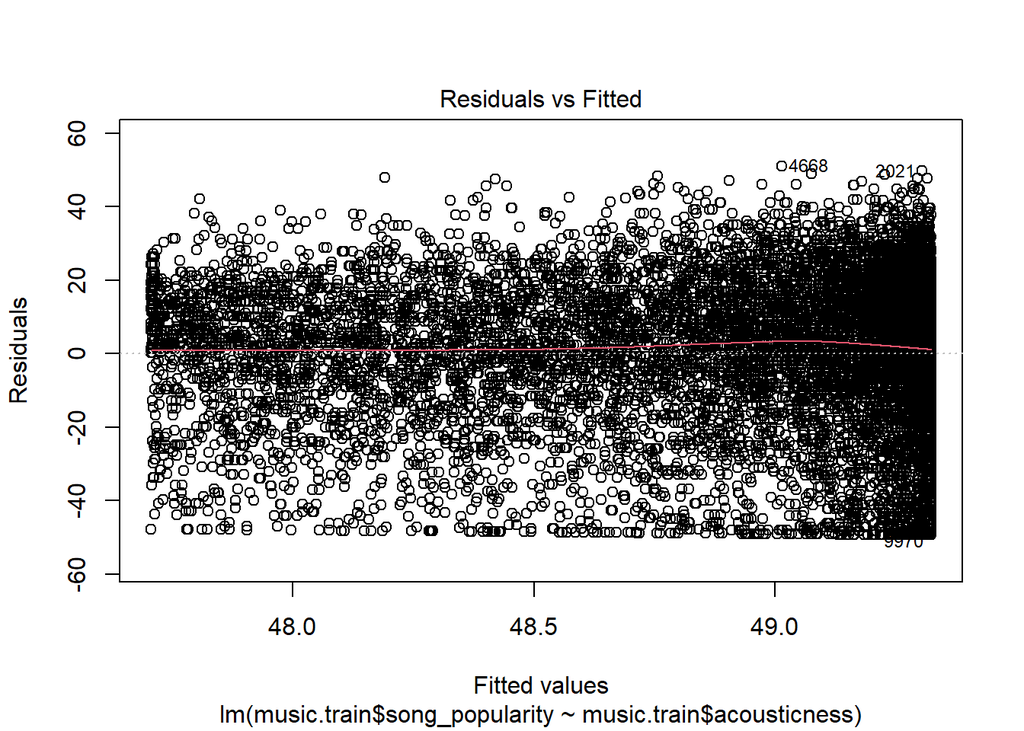

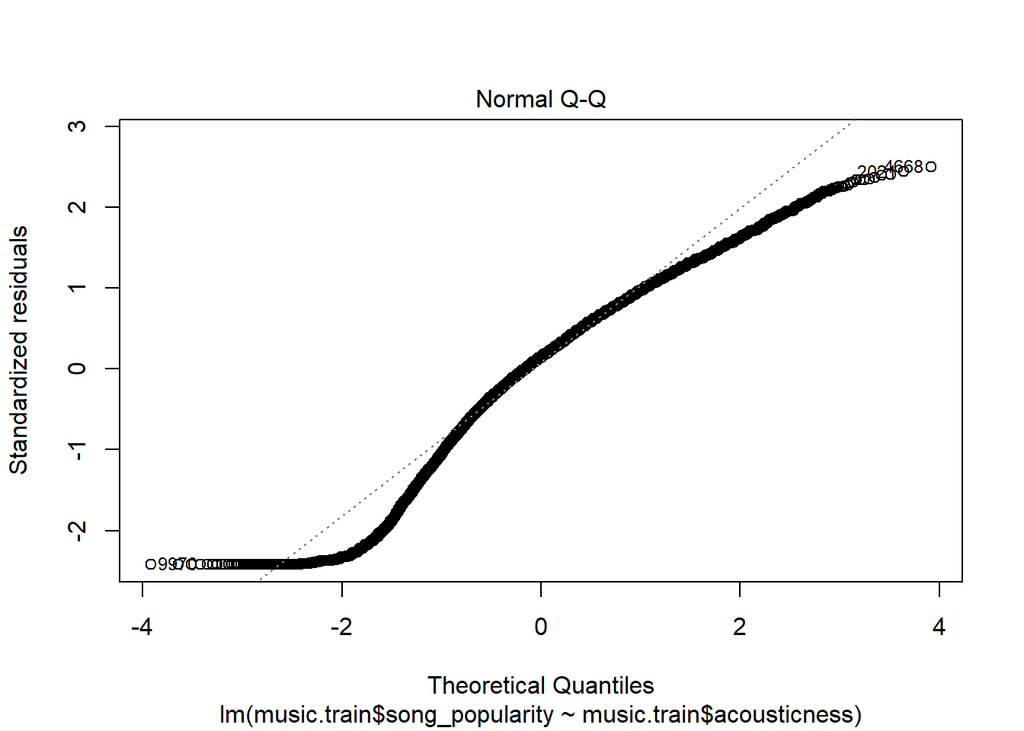

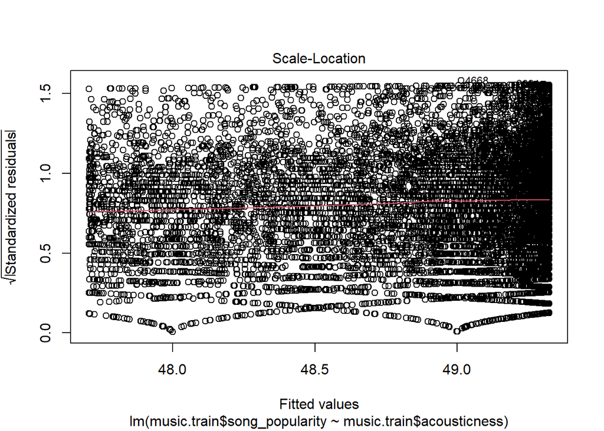

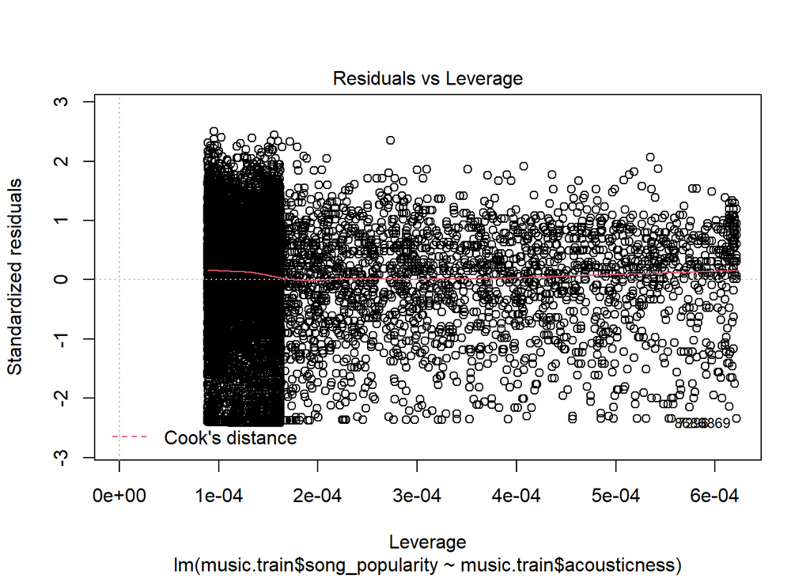

```r
plot(mod_acc)
```

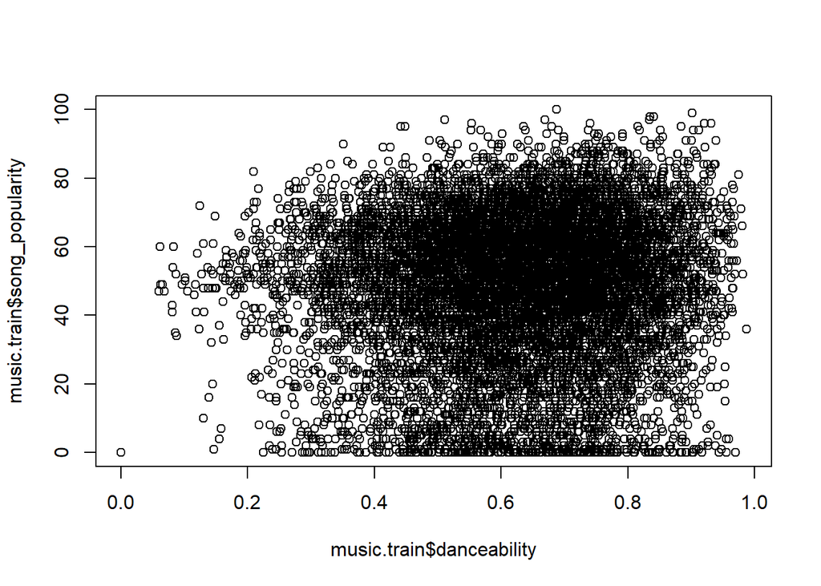

```r
plot(music.train$danceability, music.train$song_popularity)
```

```r
mod_dance = lm(music.train$song_popularity~music.train$danceability)
summary(mod_dance)
```

```
##
## Call:
## lm(formula = music.train$song_popularity ~ music.train$danceability)
##
## Residuals:
##     Min      1Q  Median      3Q     Max
## -51.553 -11.517   2.941  14.770  50.639
##
## Coefficients:
##                          Estimate Std. Error t value Pr(>|t|)
## (Intercept)               44.0397     0.7825  56.283  < 2e-16 ***
## music.train$danceability   7.7458     1.2125   6.388 1.75e-10 ***
## ---
## Signif. codes:  0 '***' 0.001 '**' 0.01 '*' 0.05 '.' 0.1 ' ' 1
##
## Residual standard error: 20.35 on 11238 degrees of freedom
## Multiple R-squared:  0.003618,   Adjusted R-squared:  0.003529
## F-statistic: 40.81 on 1 and 11238 DF,  p-value: 1.746e-10
```

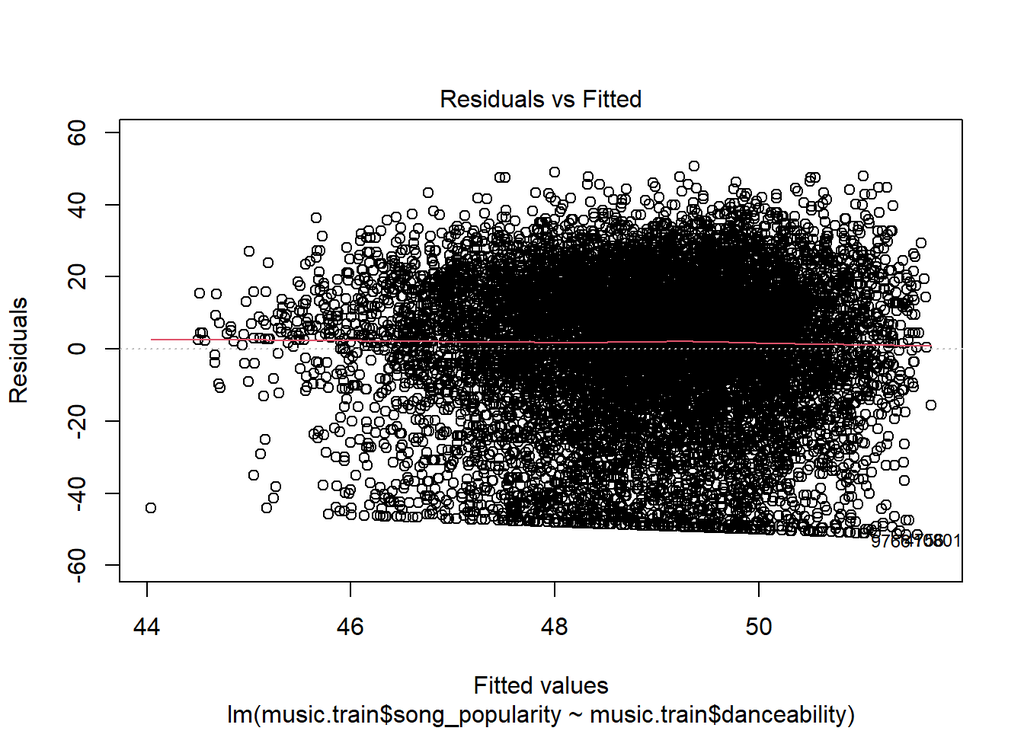

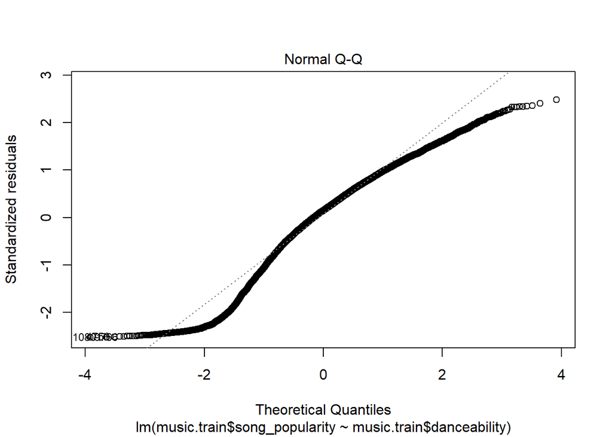

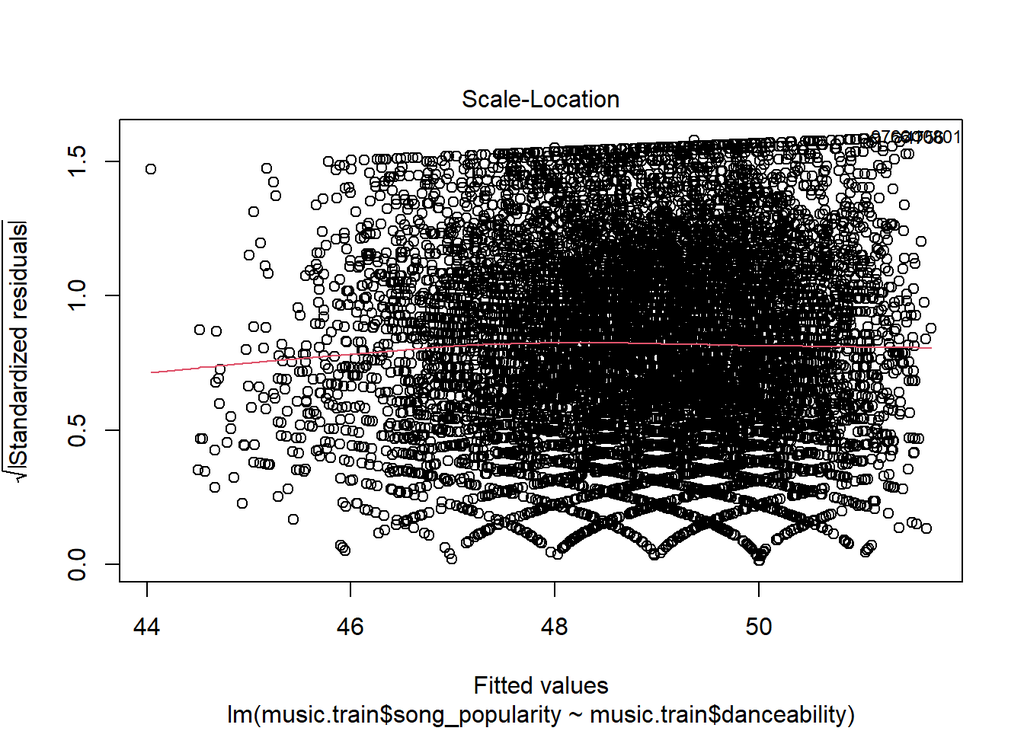

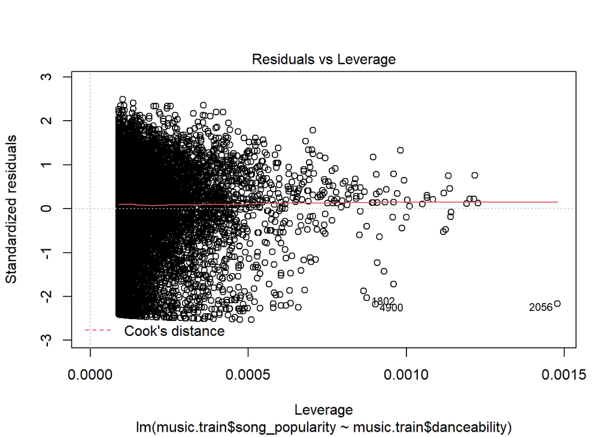

```r
plot(mod_dance)
```

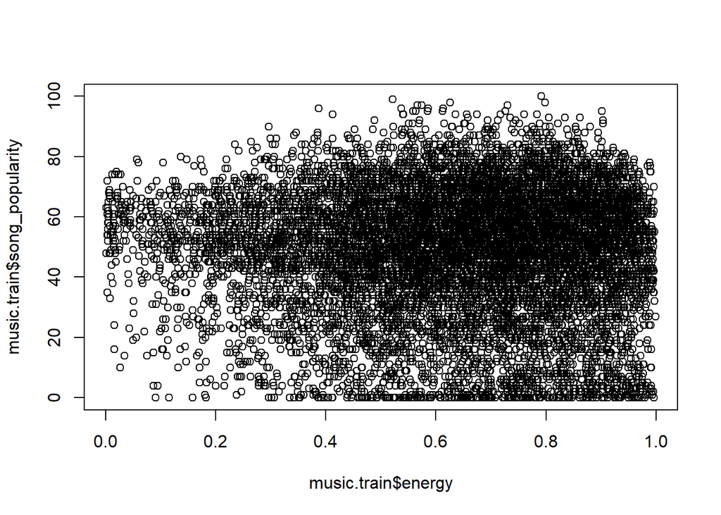

```r
plot(music.train$energy, music.train$song_popularity)
```

```r
mod_energy = lm(music.train$song_popularity~music.train$energy)
summary(mod_energy)
```

```
##
## Call:
## lm(formula = music.train$song_popularity ~ music.train$energy)
##
## Residuals:
##     Min      1Q  Median      3Q     Max
## -49.732 -11.622   2.926  14.602  51.350
##
## Coefficients:
##                    Estimate Std. Error t value Pr(>|t|)
## (Intercept)         49.8726     0.5894  84.623   <2e-16 ***
## music.train$energy  -1.5441     0.8714  -1.772   0.0764 .
## ---
## Signif. codes:  0 '***' 0.001 '**' 0.01 '*' 0.05 '.' 0.1 ' ' 1
##
## Residual standard error: 20.39 on 11238 degrees of freedom
## Multiple R-squared:  0.0002793,  Adjusted R-squared:  0.0001904
## F-statistic:  3.14 on 1 and 11238 DF,  p-value: 0.07642
```

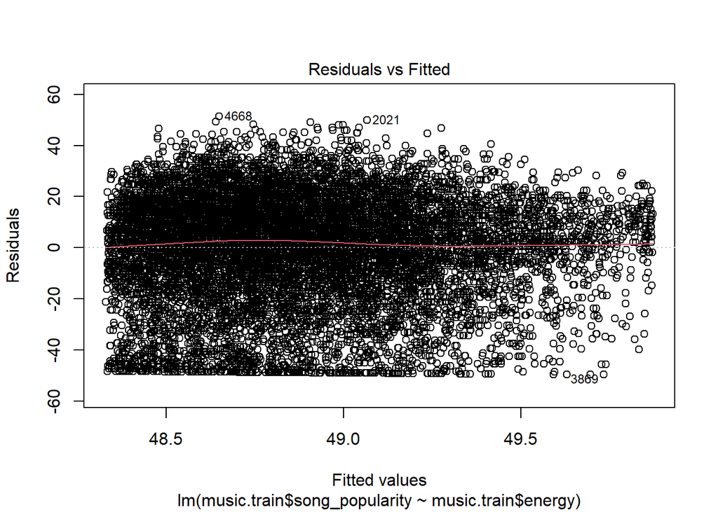

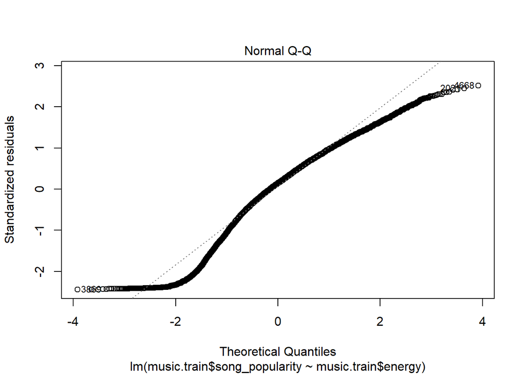

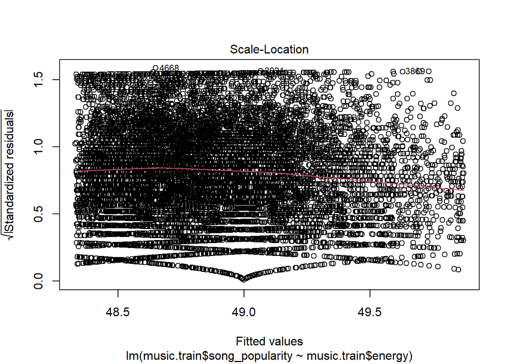

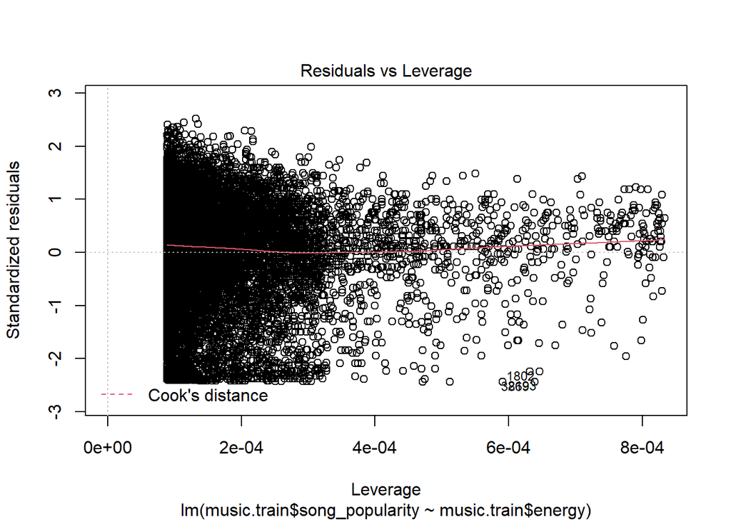

```r
plot(mod_energy)
```

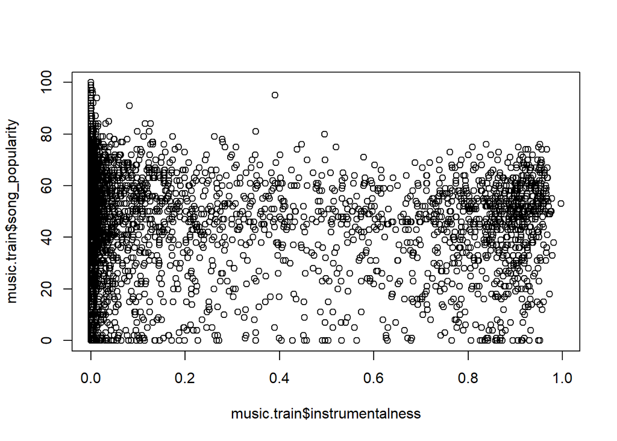

```r
plot(music.train$instrumentalness, music.train$song_popularity)
```

```r
mod_instr = lm(music.train$song_popularity~music.train$instrumentalness)
summary(mod_instr)
```

```
##
## Call:
## lm(formula = music.train$song_popularity ~ music.train$instrumentalness)
##
## Residuals:
##     Min      1Q  Median      3Q     Max
## -49.569 -11.568   3.431  14.436  50.431
##
## Coefficients:
##                              Estimate Std. Error t value Pr(>|t|)
## (Intercept)                   49.5686     0.2047 242.117   <2e-16 ***
## music.train$instrumentalness  -7.5576     0.7995  -9.453   <2e-16 ***
## ---
## Signif. codes:  0 '***' 0.001 '**' 0.01 '*' 0.05 '.' 0.1 ' ' 1
##
## Residual standard error: 20.31 on 11238 degrees of freedom
## Multiple R-squared:  0.007888,   Adjusted R-squared:  0.0078
## F-statistic: 89.35 on 1 and 11238 DF,  p-value: < 2.2e-16
```

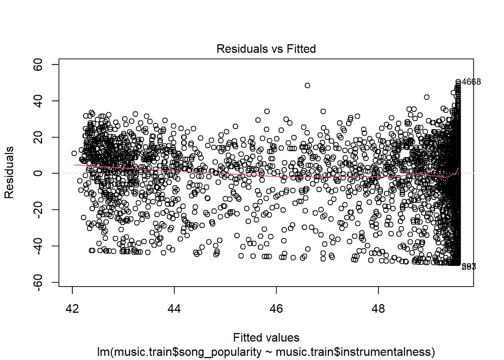

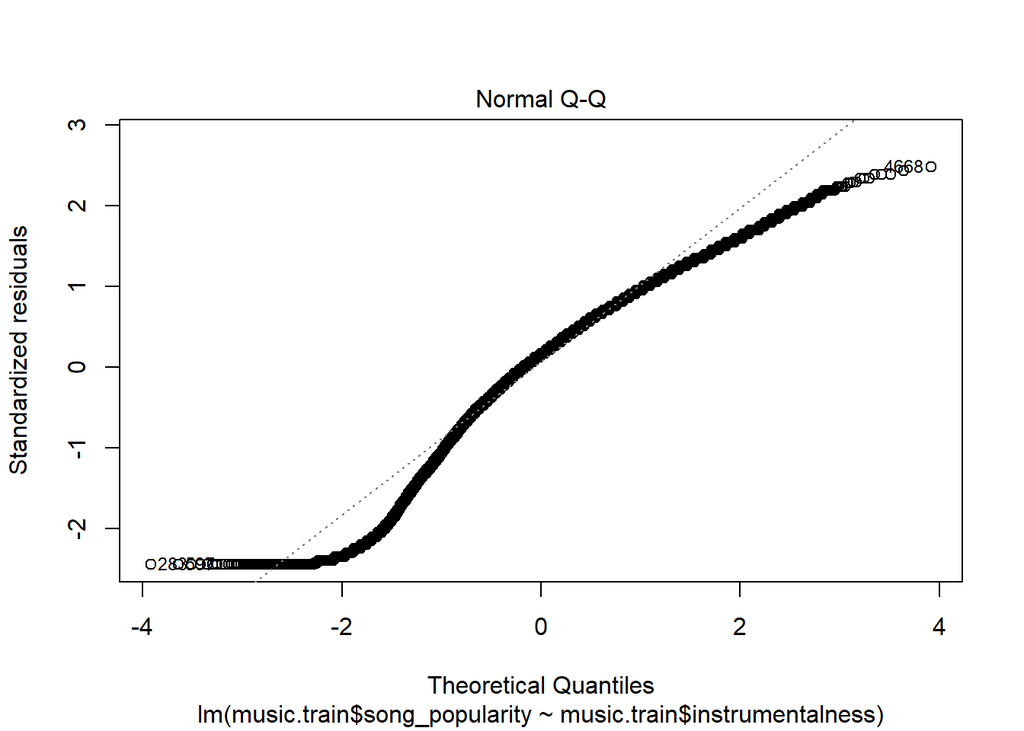

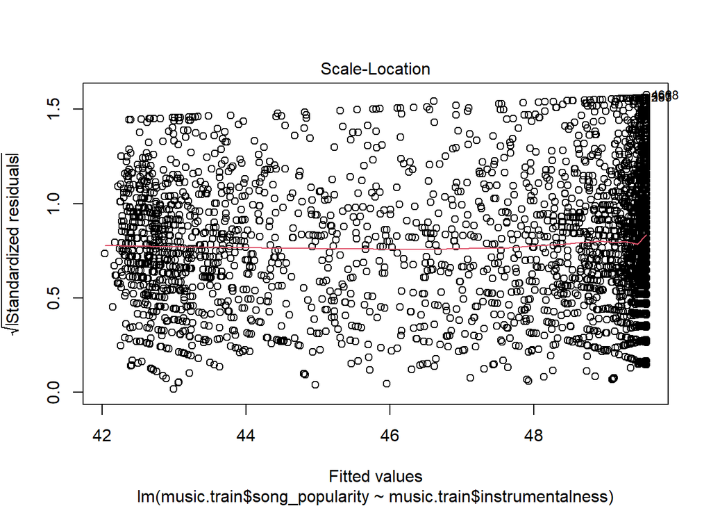

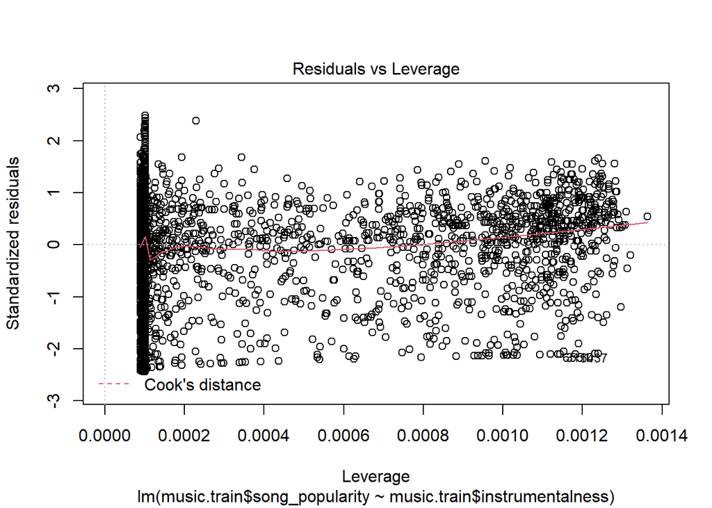

```r
plot(mod_instr)
```

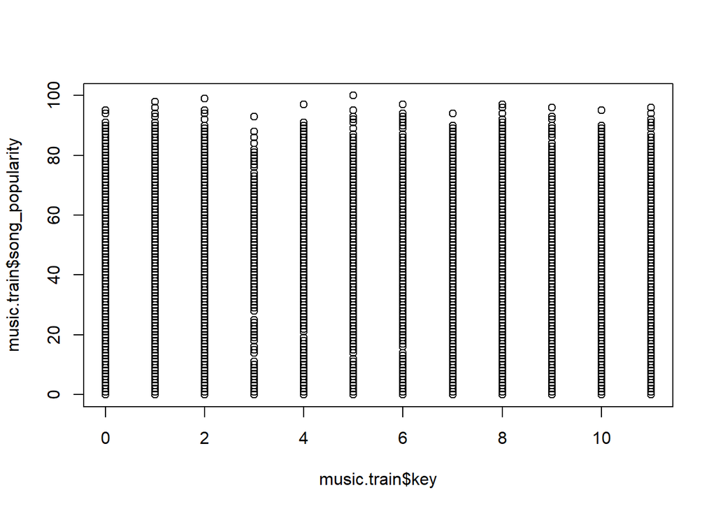

```r
plot(music.train$key, music.train$song_popularity)
```

```r
mod_key = lm(music.train$song_popularity~music.train$key)
summary(mod_key)
```

```
##
## Call:
## lm(formula = music.train$song_popularity ~ music.train$key)
##
## Residuals:
##     Min      1Q  Median      3Q     Max
## -49.033 -11.773   3.045  14.993  51.123
##
## Coefficients:
##                 Estimate Std. Error t value Pr(>|t|)
## (Intercept)     48.74669    0.34317 142.048   <2e-16 ***
## music.train$key  0.02605    0.05337   0.488    0.626
## ---
## Signif. codes:  0 '***' 0.001 '**' 0.01 '*' 0.05 '.' 0.1 ' ' 1
##
## Residual standard error: 20.39 on 11238 degrees of freedom
## Multiple R-squared:  2.119e-05,  Adjusted R-squared:  -6.779e-05
## F-statistic: 0.2382 on 1 and 11238 DF,  p-value: 0.6255
```

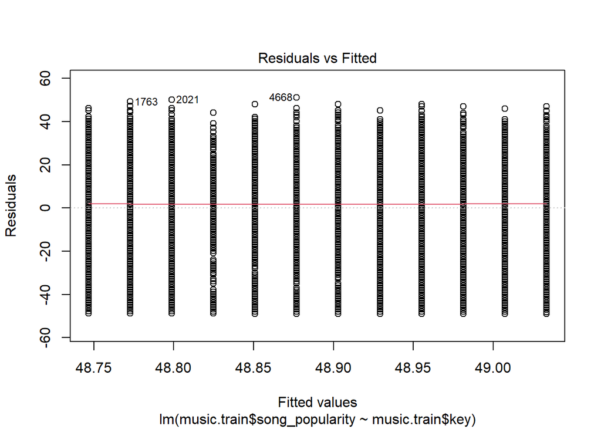

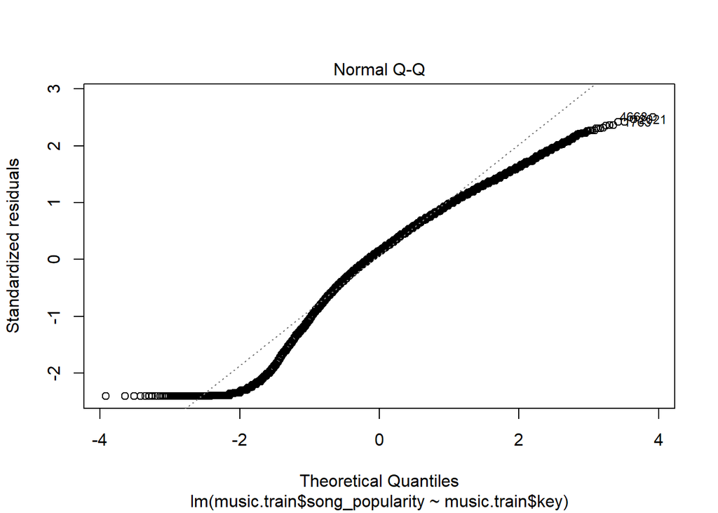

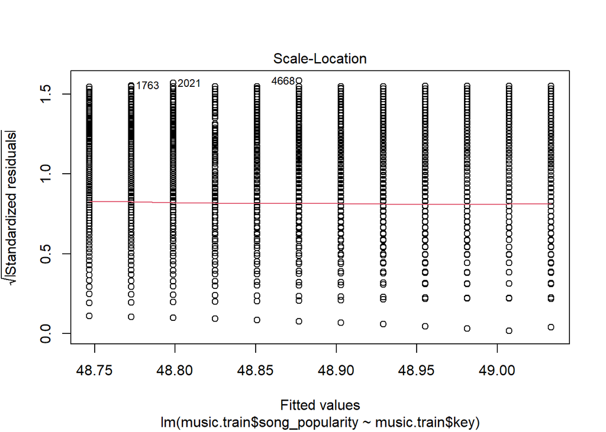

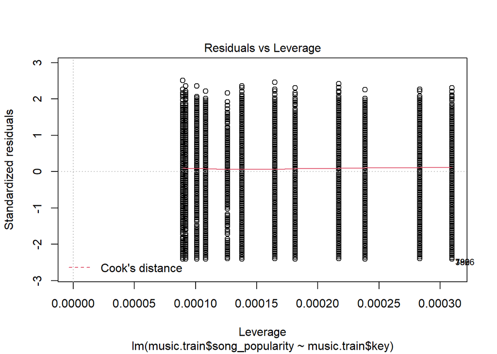

```r
plot(mod_key)
```

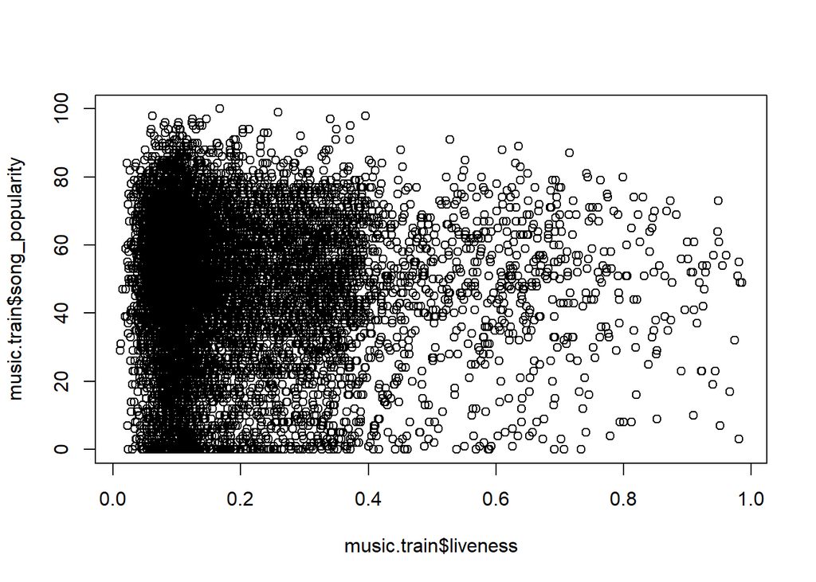

```r
plot(music.train$liveness, music.train$song_popularity)
```

```r
mod_liveness = lm(music.train$song_popularity~music.train$liveness)
summary(mod_liveness)
```

```
##
## Call:
## lm(formula = music.train$song_popularity ~ music.train$liveness)
##
## Residuals:
##     Min      1Q  Median      3Q     Max
## -49.814 -11.472   2.829  14.677  51.042
##
## Coefficients:
##                      Estimate Std. Error t value Pr(>|t|)
## (Intercept)           49.9566     0.3074 162.502  < 2e-16 ***
## music.train$liveness  -5.9793     1.3395  -4.464 8.13e-06 ***
## ---
## Signif. codes:  0 '***' 0.001 '**' 0.01 '*' 0.05 '.' 0.1 ' ' 1
##
## Residual standard error: 20.37 on 11238 degrees of freedom
## Multiple R-squared:  0.00177,    Adjusted R-squared:  0.001681
## F-statistic: 19.93 on 1 and 11238 DF,  p-value: 8.131e-06
```